# Import the necessary libraries

```python
# import the libraries
import pandas as pd
import numpy as np
import matplotlib.pyplot as plt
import seaborn as sns
sns.set(style="darkgrid")
%matplotlib inline
```

```python
#reading the concrete data
concrete_df = pd.read_csv("D:\SAI\MECH\Great Learning\Study\Featurization, Model Selection & Tuning\Project\concrete.csv")
concrete_df.head()
```

|  | cement | slag | ash | water | superplastic | coarseagg | fineagg | age | strength |
| --- | --- | --- | --- | --- | --- | --- | --- | --- | --- |
| 0 | 141.3 | 212.0 | 0.0 | 203.5 | 0.0 | 971.8 | 748.5 | 28 | 29.89 |
| 1 | 168.9 | 42.2 | 124.3 | 158.3 | 10.8 | 1080.8 | 796.2 | 14 | 23.51 |
| 2 | 250.0 | 0.0 | 95.7 | 187.4 | 5.5 | 956.9 | 861.2 | 28 | 29.22 |
| 3 | 266.0 | 114.0 | 0.0 | 228.0 | 0.0 | 932.0 | 670.0 | 28 | 45.85 |
| 4 | 154.8 | 183.4 | 0.0 | 193.3 | 9.1 | 1047.4 | 696.7 | 28 | 18.29 |

```python
#Understanding shape of data
concrete_df.shape
```

```
(1030, 9)
```

# 1(a). Univariate analysis

```python
#To show the detailed summary
concrete_df.info()
```

```
<class 'pandas.core.frame.DataFrame'>
RangeIndex: 1030 entries, 0 to 1029
Data columns (total 9 columns):
 #   Column        Non-Null Count  Dtype
---  ------        --------------  -----
 0   cement        1030 non-null   float64
 1   slag          1030 non-null   float64
 2   ash           1030 non-null   float64
 3   water         1030 non-null   float64
 4   superplastic  1030 non-null   float64
 5   coarseagg     1030 non-null   float64
 6   fineagg       1030 non-null   float64
 7   age           1030 non-null   int64
 8   strength      1030 non-null   float64
dtypes: float64(8), int64(1)
memory usage: 72.5 KB
```

**It gives the details about the number of rows (1030), number of columns (9), data types information i.e. except age which is integer type all other columns are float type**

```python
#get the summary of data
concrete_df.describe().transpose()
```

|  | count | mean | std | min | 25% | 50% | 75% | max |
| --- | --- | --- | --- | --- | --- | --- | --- | --- |
| cement | 1030.0 | 281.167864 | 104.506364 | 102.00 | 192.375 | 272.900 | 350.000 | 540.0 |
| slag | 1030.0 | 73.895825 | 86.279342 | 0.00 | 0.000 | 22.000 | 142.950 | 359.4 |
| ash | 1030.0 | 54.188350 | 63.997004 | 0.00 | 0.000 | 0.000 | 118.300 | 200.1 |
| water | 1030.0 | 181.567282 | 21.354219 | 121.80 | 164.900 | 185.000 | 192.000 | 247.0 |
| superplastic | 1030.0 | 6.204660 | 5.973841 | 0.00 | 0.000 | 6.400 | 10.200 | 32.2 |
| coarseagg | 1030.0 | 972.918932 | 77.753954 | 801.00 | 932.000 | 968.000 | 1029.400 | 1145.0 |
| fineagg | 1030.0 | 773.580485 | 80.175980 | 594.00 | 730.950 | 779.500 | 824.000 | 992.6 |
| age | 1030.0 | 45.662136 | 63.169912 | 1.00 | 7.000 | 28.000 | 56.000 | 365.0 |
| strength | 1030.0 | 35.817961 | 16.705742 | 2.33 | 23.710 | 34.445 | 46.135 | 82.6 |

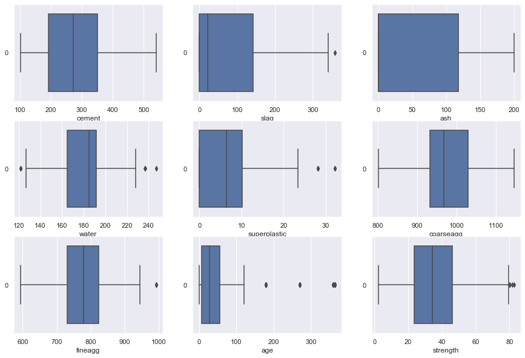

```python
#### Lets plot the box for each
plt.figure(figsize=(15,10))
pos = 1
for column in concrete_df.select_dtypes(include=[np.number]):
    plt.subplot(3, 3, pos)
    box_plot = sns.boxplot(data=concrete_df[column], orient="h")
    box_plot.set(xlabel=column)
    pos += 1
```

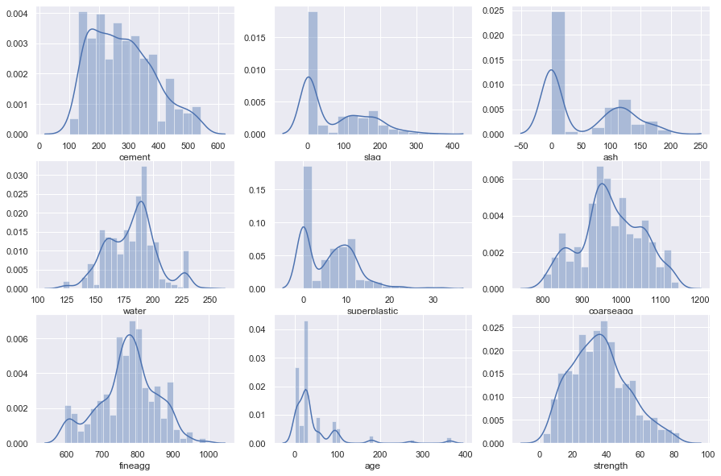

```python
#### Lets check frequsncy for each
plt.figure(figsize=(15,10))
pos = 1
for column in concrete_df.select_dtypes(include=[np.number]):
    plt.subplot(3, 3, pos)
    dist_plot=sns.distplot(concrete_df[column])
    dist_plot.set(xlabel=column)
    pos += 1
```

**observations indicate**

**cement -- Reasonably well balanced data**

**slag -- Tail at the right .. high number of 0's**

**ash -- Tail at the right ... higher number of 0's**

**water -- Resonably well balanced data, but multiple peaks**

**superplastic -- Again large number or 0's, Tail towards right**

**coarseagg -- Reasonably well balanced data**

**fineagg -- resonably well balanced data**

**age -- looks skewed with right tail,few outliers at the 300+ range**

**strength -- seems to be resonably well balanced with little outliers**

# 1(b). Bi-ivariate analysis

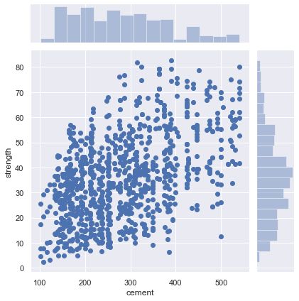

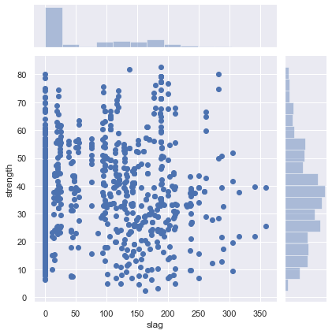

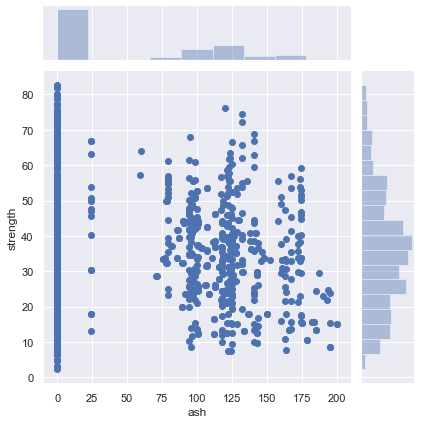

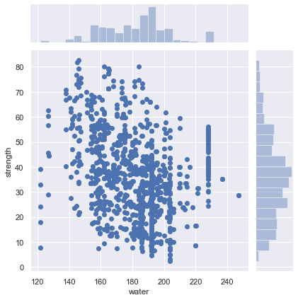

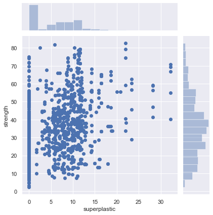

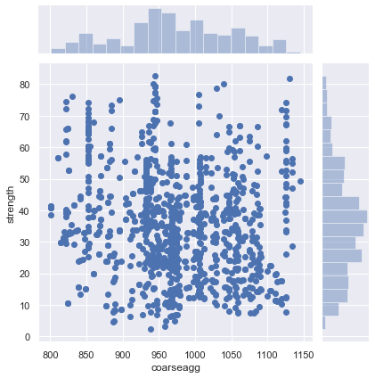

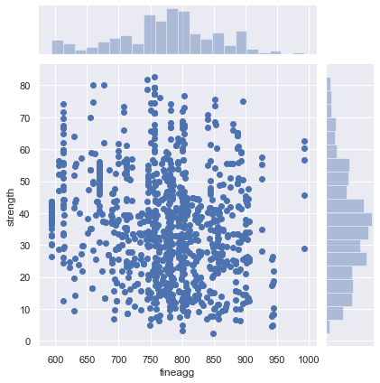

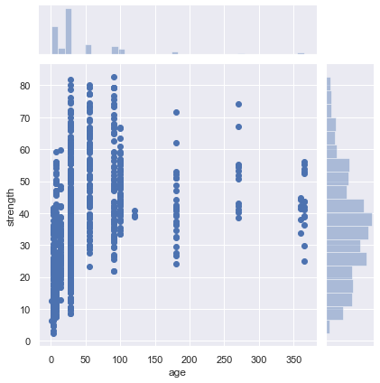

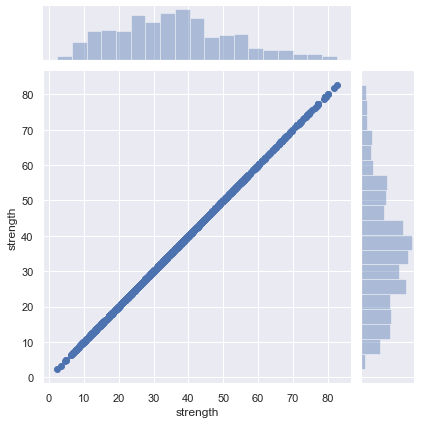

```python
#### Lets check frequsncy for each
plt.figure()
for column in concrete_df.select_dtypes(include=[np.number]):
    joint_plot = sns.jointplot(x=concrete_df[column], y=concrete_df['strength'], data=concrete_df);
```

**I dont see any strong co-relation of any individual variable with target except for-- cement and strength seem to weakly releated.. i do see strength slightly increasing with increase of cement**

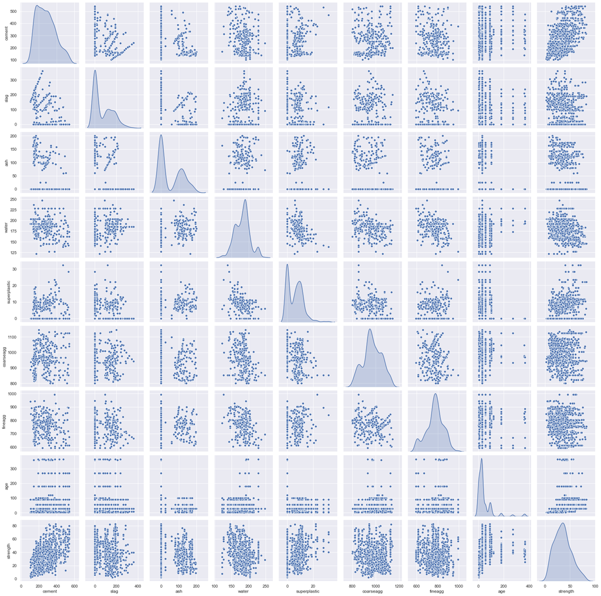

```python
#Lets pair plot.
sns.pairplot(concrete_df, diag_kind="kde");
```

# 1(c). Pick one strategy to address the presence outliers and missing values and perform necessary imputation

```python
#Checking for missing values
concrete_df.isnull().sum()
```

```
cement          0
slag            0
ash             0
water           0
superplastic    0
coarseagg       0
fineagg         0
age             0
strength        0
dtype: int64
```

**We can see that there are no missing values**

```python
#Creating copy of original dataset
concrete_df1=concrete_df.copy()
```

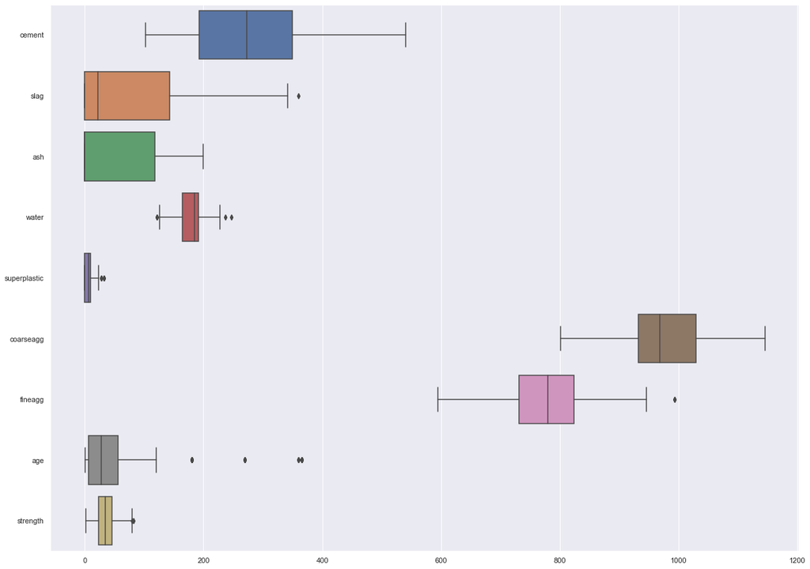

```python
# again check for outliers in dataset after handling missing values using boxplot
# A quick check to find columns that contain outliers
fig = plt.figure(figsize = (20, 15))
ax = sns.boxplot(data = concrete_df1.iloc[:, 0:9], orient = 'h')
```

```python
#Number of outliers present in the dataset
print('Number of outliers in cement: ',concrete_df1[((concrete_df1.cement - concrete_df1.cement.mean()) / concrete_df1.cement.std()).abs() >3]['cement'].count())
print('Number of outliers in slag: ',concrete_df1[((concrete_df1.slag - concrete_df1.slag.mean()) / concrete_df1.slag.std()).abs() >3]['slag'].count())
print('Number of outliers in ash: ',concrete_df1[((concrete_df1.ash - concrete_df1.ash.mean()) / concrete_df1.ash.std()).abs() >3]['ash'].count())
print('Number of outliers in water: ',concrete_df1[((concrete_df1.water - concrete_df1.water.mean()) / concrete_df1.water.std()).abs() >3]['water'].count())
print('Number of outliers in superplastic: ',concrete_df1[((concrete_df1.superplastic - concrete_df1.superplastic.mean()) / concrete_df1.superplastic.std()).abs() >3]['superplastic'].count())
print('Number of outliers in coarseagg: ',concrete_df1[((concrete_df1.coarseagg - concrete_df1.coarseagg.mean()) / concrete_df1.coarseagg.std()).abs() >3]['coarseagg'].count())
print('Number of outliers in fineagg: ',concrete_df1[((concrete_df1.fineagg - concrete_df1.fineagg.mean()) / concrete_df1.fineagg.std()).abs() >3]['fineagg'].count())
print('Number of outliers in age: ',concrete_df1[((concrete_df1.age - concrete_df1.age.mean()) / concrete_df1.age.std()).abs() >3]['age'].count())
```

```
Number of outliers in cement:  0
Number of outliers in slag:  4
Number of outliers in ash:  0
Number of outliers in water:  2
Number of outliers in superplastic:  10
Number of outliers in coarseagg:  0
Number of outliers in fineagg:  0
Number of outliers in age:  33
```

**Here, we have used Standard deviation method to detect the outliers.If we have any data point that is more than 3 times the standard deviation, then those points are very likely to be outliers.**

**We can see that slag, water, superplastic and age contain outliers.**

```python
#Records which contains the outliers in slag attribute
print('Records containing outliers in slag: \n',concrete_df1[((concrete_df1.slag - concrete_df1.slag.mean()) / concrete_df1.slag.std()).abs() >3]['slag'])
```

```
Records containing outliers in slag:
 21     342.1
564    342.1
918    359.4
990    359.4
Name: slag, dtype: float64
```

```python
#Records which contains the outliers in water attribute
print('Records containing outliers in water: \n',concrete_df1[((concrete_df1.water - concrete_df1.water.mean()) / concrete_df1.water.std()).abs() >3]['water'])
```

```
Records containing outliers in water:
 66     247.0
263    246.9
Name: water, dtype: float64
```

```python
#Records which contains the outliers in superplastic attribute
print('Records containing outliers in superplastic: \n',concrete_df1[((concrete_df1.superplastic - concrete_df1.superplastic.mean()) / concrete_df1.superplastic.std()).abs() >3]['superplastic'])
```

```
Records containing outliers in superplastic:
 44      28.2
156     28.2
232     32.2
292     32.2
538     28.2
744     32.2
816     32.2
838     28.2
955     32.2
1026    28.2
Name: superplastic, dtype: float64
```

```python
#Records which contains the outliers in age attribute
print('Records containing outliers in age: \n',concrete_df1[((concrete_df1.age - concrete_df1.age.mean()) / concrete_df1.age.std()).abs() >3]['age'])
```

```
Records containing outliers in age:
 64      365
133     365
149     270
157     360
159     365
198     365
256     270
262     270
270     270
297     270
313     270
323     360
361     360
393     365
```

[output cut: 20 more lines]

# **Handling the outliers**

```python
#Replacing the outliers by median
for col_name in concrete_df1.columns[:-1]:
    q1 = concrete_df1[col_name].quantile(0.25)
    q3 = concrete_df1[col_name].quantile(0.75)
    iqr = q3 - q1

    low = q1-1.5*iqr
    high = q3+1.5*iqr
    concrete_df1.loc[(concrete_df1[col_name] < low) | (concrete_df1[col_name] > high), col_name] = concrete_df1[col_name].median()
```

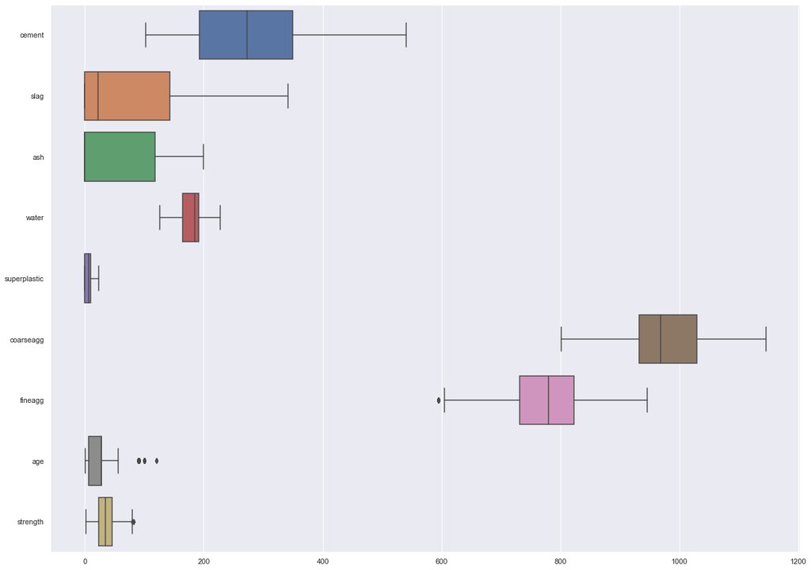

```python
# again check for outliers in dataset using boxplot
fig = plt.figure(figsize = (20, 15))
ax = sns.boxplot(data = concrete_df1.iloc[:, 0:9], orient = 'h')
```

```python
# Check co-relation
corr = concrete_df1.corr()
corr
```

|  | cement | slag | ash | water | superplastic | coarseagg | fineagg | age | strength |
| --- | --- | --- | --- | --- | --- | --- | --- | --- | --- |
| cement | 1.000000 | -0.275046 | -0.397467 | -0.091614 | 0.013336 | -0.109349 | -0.238698 | -0.031962 | 0.497832 |
| slag | -0.275046 | 1.000000 | -0.320468 | 0.098880 | 0.061195 | -0.283882 | -0.282383 | -0.028971 | 0.137800 |
| ash | -0.397467 | -0.320468 | 1.000000 | -0.248011 | 0.447492 | -0.009961 | 0.091729 | 0.057928 | -0.105755 |
| water | -0.091614 | 0.098880 | -0.248011 | 1.000000 | -0.658056 | -0.156928 | -0.426299 | -0.040304 | -0.307711 |
| superplastic | 0.013336 | 0.061195 | 0.447492 | -0.658056 | 1.000000 | -0.224503 | 0.156591 | 0.062013 | 0.346260 |
| coarseagg | -0.109349 | -0.283882 | -0.009961 | -0.156928 | -0.224503 | 1.000000 | -0.161377 | 0.018078 | -0.164935 |
| fineagg | -0.238698 | -0.282383 | 0.091729 | -0.426299 | 0.156591 | -0.161377 | 1.000000 | 0.051532 | -0.182186 |
| age | -0.031962 | -0.028971 | 0.057928 | -0.040304 | 0.062013 | 0.018078 | 0.051532 | 1.000000 | 0.499850 |
| strength | 0.497832 | 0.137800 | -0.105755 | -0.307711 | 0.346260 | -0.164935 | -0.182186 | 0.499850 | 1.000000 |

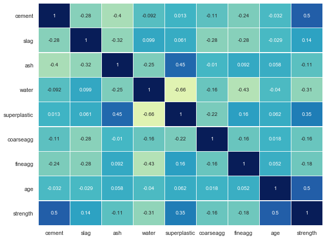

```python
#graphical representation of heatmap
plt.subplots(figsize=(10,8))
sns.heatmap(corr,annot=True,linewidths=.5,center=0,cbar=False,cmap="YlGnBu");
```

# 2. Deliverable -2 (Feature Engineering techniques)

# a. Identify opportunities (if any) to create a composite feature, drop a feature etc.

```python
#Import zscore
from scipy.stats import zscore
#Scaling the dataset
concrete_df_z = concrete_df1.apply(zscore)
concrete_df_z=pd.DataFrame(concrete_df_z,columns=concrete_df.columns)
```

```python
#independent and dependent variables
X=concrete_df_z.iloc[:,0:8]
y = concrete_df_z.iloc[:,8]
```

```python
##Split into training and test set
from sklearn.model_selection import train_test_split
# Split X and y into training and test set in 70:30 ratio
X_train, X_test, y_train, y_test = train_test_split(X,y, test_size = 0.3, random_state = 1)
```

```python
from sklearn.linear_model import LinearRegression
from sklearn.metrics import mean_squared_error, r2_score

model = LinearRegression()
model.fit(X_train, y_train)
y_pred = model.predict(X_test)

rmse = np.sqrt(mean_squared_error(y_test,y_pred))
r2 = r2_score(y_test,y_pred)
print(rmse)
print(r2)

#Initialize Result Array for summary
result = pd.DataFrame({'Model' : ['Linear Regression'], 'RMS' : [rmse], 'r2' : [r2],
                      'Comments' : 'Low accuracy explains [r2] percent fit and high error'})
```

```
0.5613390769189093
0.6981381588376172
```

```python
# Make Poly
from sklearn.preprocessing import PolynomialFeatures

polynomial_features = PolynomialFeatures(3)

X_train_poly = polynomial_features.fit_transform(X_train)
X_test_poly = polynomial_features.fit_transform(X_test)

model = LinearRegression()
model.fit(X_train_poly, y_train)
y_poly_pred = model.predict(X_test_poly)

rmse = np.sqrt(mean_squared_error(y_test,y_poly_pred))
r2 = r2_score(y_test,y_poly_pred)
print(rmse)
print(r2)

result.loc[1] = ['Linear Reg Polynomial (Deg=3)', rmse, r2, 'good accuracy and low error']
```

```
0.3602964713478131
0.8756408680570978
```

**Looks like Degree 3 fitting is giving us good accuracy with lesser RMSE**

```python
X_poly = polynomial_features.fit_transform(X)
X_poly.shape
```

```
(1030, 165)
```

# 2(c) Explore for gaussians. If data is likely to be a mix of gaussians, explore individual clusters and present your findings in terms of the independent attributes and their suitability to predict strength

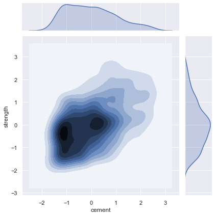

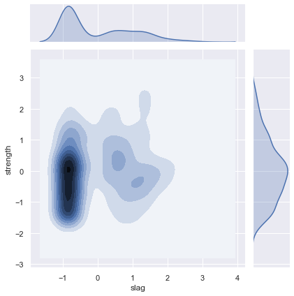

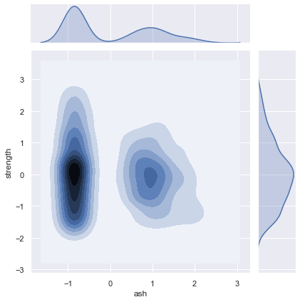

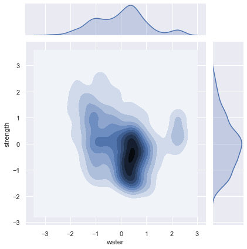

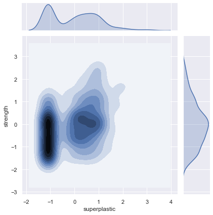

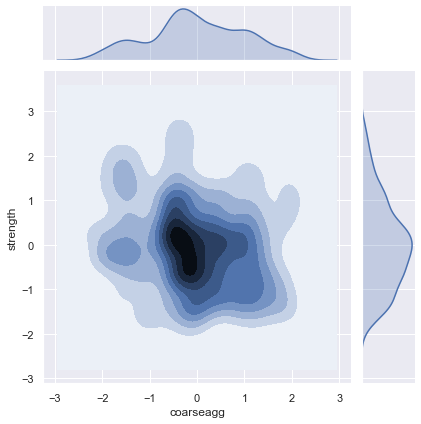

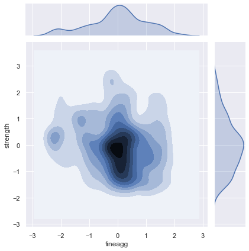

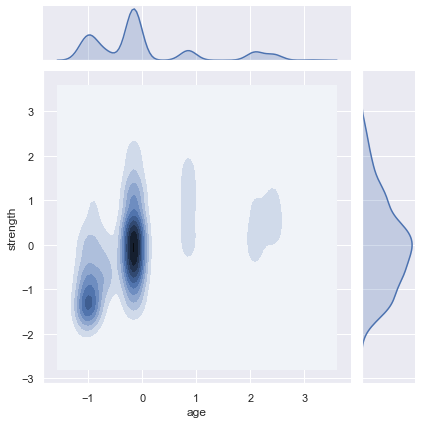

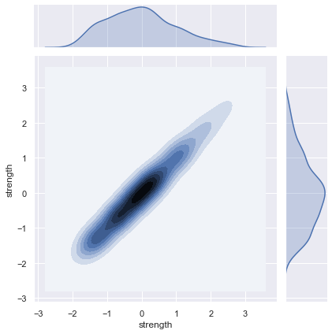

```python
#### LEts check cluster for each variable vs target
plt.figure()
for column in concrete_df1.select_dtypes(include=[np.number]):
    joint_plot = sns.jointplot(x=concrete_df_z[column], y=concrete_df_z['strength'], data=concrete_df_z, kind='kde');
```

```python
#### generate the linkage matrix
from scipy.cluster.hierarchy import dendrogram, linkage
Z = linkage(X_poly, 'ward', metric='euclidean')
Z.shape
```

```
(1029, 4)
```

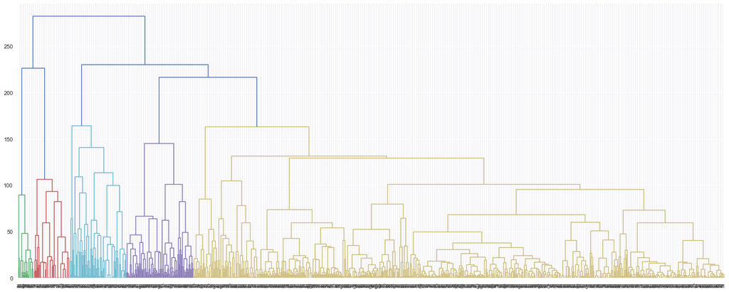

```python
plt.figure(figsize=(25, 10))
dendrogram(Z)
plt.show()
```

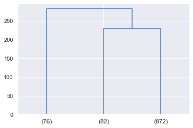

```python
dendrogram(
    Z,
    truncate_mode='lastp',  # show only the last p merged clusters
    p=3,  # show only the last p merged clusters
)
plt.show()
```

# 3 Obtain feature importance for the individual features and present your findings

```python
from sklearn.ensemble import ExtraTreesRegressor

# Build a forest and compute the feature importances
forest = ExtraTreesRegressor(n_estimators=250,
                              random_state=0)

forest.fit(X, y)
importances = forest.feature_importances_
std = np.std([tree.feature_importances_ for tree in forest.estimators_],
             axis=0)
indices = np.argsort(importances)[::-1]

header = list(X.columns)

# Print the feature ranking
print("Feature ranking:")

for f in range(X.shape[1]):
    print("%d. feature %d %s (%f)" % (f + 1, indices[f], header[indices[f]], importances[indices[f]]))
```

```
Feature ranking:
1. feature 7 age (0.360738)
2. feature 0 cement (0.256554)
3. feature 3 water (0.099568)
4. feature 1 slag (0.090209)
5. feature 4 superplastic (0.081937)
6. feature 6 fineagg (0.039655)
7. feature 2 ash (0.037976)
8. feature 5 coarseagg (0.033364)
```

```python
forest.fit(X_poly, y)
importances = forest.feature_importances_
std = np.std([tree.feature_importances_ for tree in forest.estimators_],
             axis=0)
indices = np.argsort(importances)[::-1]

# Print the feature ranking
print("Feature ranking:")

for f in range(X_poly.shape[1]):
    print("%d. feature %d (%f)" % (f + 1, indices[f], importances[indices[f]]))
```

```
Feature ranking:
1. feature 8 (0.168229)
2. feature 1 (0.087243)
3. feature 114 (0.041383)
4. feature 164 (0.037718)
5. feature 53 (0.033799)
6. feature 60 (0.030519)
7. feature 16 (0.026827)
8. feature 44 (0.026458)
9. feature 4 (0.023460)
10. feature 38 (0.018254)
11. feature 80 (0.015879)
12. feature 154 (0.015428)
13. feature 45 (0.015303)
14. feature 5 (0.014634)
15. feature 2 (0.013888)
16. feature 54 (0.012874)
17. feature 87 (0.012707)
18. feature 10 (0.012323)
19. feature 110 (0.011363)
20. feature 46 (0.010973)
21. feature 123 (0.010287)
22. feature 52 (0.009993)
23. feature 9 (0.009856)
24. feature 23 (0.008500)
25. feature 26 (0.008347)
26. feature 111 (0.007910)
27. feature 34 (0.007514)
28. feature 148 (0.007497)
29. feature 66 (0.006701)
30. feature 83 (0.006605)
31. feature 29 (0.006517)
32. feature 3 (0.006075)
33. feature 25 (0.006028)
34. feature 59 (0.005887)
35. feature 88 (0.005782)
36. feature 12 (0.005744)
37. feature 144 (0.005538)
38. feature 108 (0.005044)
39. feature 84 (0.004891)
```

[output cut: 111 more lines]

```
151. feature 101 (0.000992)
152. feature 159 (0.000989)
153. feature 152 (0.000948)
154. feature 92 (0.000932)
155. feature 151 (0.000931)
156. feature 106 (0.000881)
157. feature 86 (0.000854)
158. feature 127 (0.000851)
159. feature 107 (0.000850)
160. feature 68 (0.000827)
161. feature 22 (0.000809)
162. feature 72 (0.000795)
163. feature 97 (0.000762)
164. feature 158 (0.000740)
165. feature 0 (0.000000)
```

**Method 1 :: Using extra trees regressor ensemble for checking feature importance on both X and X_Poly..**

**for Non-Poly, the age,cement & water seem to be very important features**

**for Poly, its difficult to see what derivative is important.. but its listed in descending order**

```python
from sklearn.linear_model import LinearRegression
from sklearn.linear_model import Ridge

lr = LinearRegression()
lr.fit(X_train, y_train)
rr = Ridge(alpha=0.2) # higher the alpha value, more restriction on the coefficients; low alpha > more generalization, coefficients are barely
# restricted and in this case linear and ridge regression resembles
rr.fit(X_train, y_train)
train_score=lr.score(X_train, y_train)
test_score=lr.score(X_test, y_test)
Ridge_train_score = rr.score(X_train,y_train)
Ridge_test_score = rr.score(X_test, y_test)
coeff_used = np.sum(rr.coef_!=0)


print ("linear regression train score: ", train_score)
print ("linear regression test score: ", test_score)

print ("ridge regression train score low alpha: ", Ridge_train_score)
print ("ridge regression test score low alpha: ", Ridge_test_score)
print ("number of features used: for low alpha", coeff_used)


#print (rr.coef_)

indices = np.argsort(rr.coef_)[::-1]

header = list(X.columns)

# Print the feature ranking
print("Feature ranking low alpha ridge:")

for f in range(X.shape[1]):
    print("%d. feature %d %s (%f)" % (f + 1, indices[f], header[indices[f]], rr.coef_[indices[f]]))

rmse = mean_squared_error(y_test,rr.predict(X_test))
r2 = r2_score(y_test,rr.predict(X_test))

result.loc[2] = ['Linear Reg Ridge(alpha=0.2)', rmse, r2, 'low accuracy and high error']
```

```
linear regression train score:  0.7214971210103257
linear regression test score:  0.6981381588376172
ridge regression train score low alpha:  0.7214967714081777
ridge regression test score low alpha:  0.698137168493681
number of features used: for low alpha 8
Feature ranking low alpha ridge:
1. feature 0 cement (0.631570)
2. feature 7 age (0.518914)
3. feature 1 slag (0.331200)
4. feature 2 ash (0.124791)
5. feature 4 superplastic (0.106140)
6. feature 5 coarseagg (-0.036778)
7. feature 6 fineagg (-0.050835)
8. feature 3 water (-0.205662)
```

```python
rr1 = Ridge(alpha=1) #  comparison with alpha value
rr1.fit(X_train, y_train)

Ridge_train_score1 = rr1.score(X_train,y_train)
Ridge_test_score1 = rr1.score(X_test, y_test)
coeff_used_1 = np.sum(rr1.coef_!=0)

print ("ridge regression train score high alpha: ", Ridge_train_score1)
print ("ridge regression test score high alpha: ", Ridge_test_score1)
print ("number of features used: for high alpha", coeff_used_1)

#print (rr1.coef_)

indices = np.argsort(rr1.coef_)[::-1]

header = list(X.columns)

# Print the feature ranking
print("Feature ranking high alpha ridge:")

for f in range(X.shape[1]):
    print("%d. feature %d %s (%f)" % (f + 1, indices[f], header[indices[f]], rr1.coef_[indices[f]]))

rmse = mean_squared_error(y_test,rr1.predict(X_test))
r2 = r2_score(y_test,rr1.predict(X_test))

result.loc[3] = ['Linear Reg Ridge(alpha=1)', rmse, r2, 'low accuracy and high error']
```

```
ridge regression train score high alpha:  0.7214887291754133
ridge regression test score high alpha:  0.698125843701608
number of features used: for high alpha 8
Feature ranking high alpha ridge:
1. feature 0 cement (0.626381)
2. feature 7 age (0.518350)
3. feature 1 slag (0.326422)
4. feature 2 ash (0.120518)
5. feature 4 superplastic (0.106513)
6. feature 5 coarseagg (-0.039579)
7. feature 6 fineagg (-0.054527)
8. feature 3 water (-0.208257)
```

```python
from sklearn.linear_model import Lasso

lasso02 = Lasso(alpha=0.02, max_iter=10e5)
lasso02.fit(X_train,y_train)
train_score02=lasso02.score(X_train,y_train)
test_score02=lasso02.score(X_test,y_test)
coeff_used02 = np.sum(lasso02.coef_!=0)
print ("training score for alpha=0.02:", train_score02 )
print ("test score for alpha =0.02: ", test_score02)
print ("number of features used: for alpha =0.02:", coeff_used02)

#print (lasso02.coef_)

print("Feature ranking low alpha lasso:")

indices = np.argsort(lasso02.coef_)[::-1]

header = list(X.columns)

for f in range(X.shape[1]):
    print("%d. feature %d %s (%f)" % (f + 1, indices[f], header[indices[f]], lasso02.coef_[indices[f]]))

rmse = mean_squared_error(y_test,lasso02.predict(X_test))
r2 = r2_score(y_test,lasso02.predict(X_test))

result.loc[4] = ['Linear Reg lasso (alpha=0.02)', rmse, r2, 'low accuracy and high error']
```

```
training score for alpha=0.02: 0.7165019232627645
test score for alpha =0.02:  0.6879607445805187
number of features used: for alpha =0.02: 8
Feature ranking low alpha lasso:
1. feature 0 cement (0.555381)
2. feature 7 age (0.494933)
3. feature 1 slag (0.257766)
4. feature 4 superplastic (0.145875)
5. feature 2 ash (0.037001)
6. feature 5 coarseagg (-0.034206)
7. feature 6 fineagg (-0.054814)
8. feature 3 water (-0.182030)
```

```python
lasso2 = Lasso(alpha=0.2, max_iter=10e5)
lasso2.fit(X_train,y_train)
train_score2=lasso2.score(X_train,y_train)
test_score2=lasso2.score(X_test,y_test)
coeff_used2 = np.sum(lasso2.coef_!=0)
print ("training score for alpha=0.2:", train_score2 )
print ("test score for alpha =0.2: ", test_score2)
print ("number of features used: for alpha =0.2:", coeff_used2)

#print (lasso02.coef_)

print("Feature ranking low alpha lasso:")

indices = np.argsort(lasso2.coef_)[::-1]

header = list(X.columns)

for f in range(X.shape[1]):
    print("%d. feature %d %s (%f)" % (f + 1, indices[f], header[indices[f]], lasso2.coef_[indices[f]]))

rmse = mean_squared_error(y_test,lasso2.predict(X_test))
r2 = r2_score(y_test,lasso2.predict(X_test))

result.loc[5] = ['Linear Reg lasso(alpha=0.2)', rmse, r2, 'very low accuracy and low error']
```

```
training score for alpha=0.2: 0.5083462926294788
test score for alpha =0.2:  0.4793953631196486
number of features used: for alpha =0.2: 5
Feature ranking low alpha lasso:
1. feature 0 cement (0.319266)
2. feature 7 age (0.302353)
3. feature 4 superplastic (0.107848)
4. feature 1 slag (0.015937)
5. feature 6 fineagg (-0.000000)
6. feature 5 coarseagg (-0.000000)
7. feature 2 ash (-0.000000)
8. feature 3 water (-0.003150)
```

**Using Ridge and lasso, we can see that we get different important featuers.. But lasso accuracy had dropped badly., hence it might not be good idea**

```python
# Ridge Lasso on polynomial

lr = LinearRegression()
lr.fit(X_train_poly, y_train)
rr = Ridge(alpha=0.2) # higher the alpha value, more restriction on the coefficients; low alpha > more generalization, coefficients are barely
# restricted and in this case linear and ridge regression resembles
rr.fit(X_train_poly, y_train)
train_score=lr.score(X_train_poly, y_train)
test_score=lr.score(X_test_poly, y_test)
Ridge_train_score = rr.score(X_train_poly,y_train)
Ridge_test_score = rr.score(X_test_poly, y_test)
coeff_used = np.sum(rr.coef_!=0)


print ("linear regression train score: ", train_score)
print ("linear regression test score: ", test_score)

print ("ridge regression train score low alpha: ", Ridge_train_score)
print ("ridge regression test score low alpha: ", Ridge_test_score)
print ("number of features used: for low alpha", coeff_used)


#print (rr.coef_)

indices = np.argsort(rr.coef_)[::-1]

# Print the feature ranking
print("Feature ranking low alpha ridge poly input :")

for f in range(X_poly.shape[1]):
    print("%d. feature %d (%f)" % (f + 1, indices[f], rr.coef_[indices[f]]))

rmse = mean_squared_error(y_test,rr.predict(X_test_poly))
r2 = r2_score(y_test,rr.predict(X_test_poly))

result.loc[6] = ['Linear Reg ridge (poly=3)(alpha=0.2)', rmse, r2, 'High accuracy']
```

```
linear regression train score:  0.9419719814677286
linear regression test score:  0.875640868057098
ridge regression train score low alpha:  0.9404558296252715
ridge regression test score low alpha:  0.8799780966258905
number of features used: for low alpha 164
Feature ranking low alpha ridge poly input :
1. feature 1 (0.839516)
2. feature 8 (0.694022)
3. feature 91 (0.557945)
4. feature 85 (0.544693)
5. feature 2 (0.536296)
6. feature 104 (0.528270)
7. feature 3 (0.417112)
8. feature 103 (0.405960)
9. feature 96 (0.308899)
10. feature 83 (0.302495)
11. feature 7 (0.288577)
12. feature 6 (0.280172)
13. feature 23 (0.269485)
14. feature 57 (0.259707)
15. feature 24 (0.235118)
16. feature 89 (0.232078)
17. feature 97 (0.225250)
18. feature 106 (0.178461)
19. feature 20 (0.173987)
20. feature 112 (0.169496)
21. feature 13 (0.163208)
22. feature 16 (0.155642)
23. feature 161 (0.153849)
24. feature 164 (0.139467)
25. feature 36 (0.130064)
26. feature 88 (0.128964)
27. feature 101 (0.121192)
28. feature 37 (0.115132)
29. feature 158 (0.109056)
30. feature 102 (0.105891)
31. feature 142 (0.103463)
32. feature 29 (0.099724)
33. feature 43 (0.094203)
34. feature 81 (0.087854)
```

[output cut: 116 more lines]

```
151. feature 28 (-0.306078)
152. feature 118 (-0.309267)
153. feature 92 (-0.321395)
154. feature 11 (-0.330095)
155. feature 72 (-0.332228)
156. feature 10 (-0.335831)
157. feature 54 (-0.338739)
158. feature 58 (-0.359222)
159. feature 47 (-0.372302)
160. feature 125 (-0.391988)
161. feature 18 (-0.412252)
162. feature 51 (-0.438963)
163. feature 121 (-0.490636)
164. feature 44 (-0.492755)
165. feature 64 (-0.743524)
```

```python
from sklearn.linear_model import Lasso

lasso02 = Lasso(alpha=0.02, max_iter=10e5)
lasso02.fit(X_train_poly,y_train)
train_score02=lasso02.score(X_train_poly,y_train)
test_score02=lasso02.score(X_test_poly,y_test)
coeff_used02 = np.sum(lasso02.coef_!=0)
print ("training score for alpha=0.02:", train_score02 )
print ("test score for alpha =0.02: ", test_score02)
print ("number of features used: for alpha =0.02:", coeff_used02)

#print (lasso02.coef_)

print("Feature ranking low alpha lasso:")

indices = np.argsort(lasso02.coef_)[::-1]

for f in range(X_poly.shape[1]):
    print("%d. feature %d (%f)" % (f + 1, indices[f], lasso02.coef_[indices[f]]))

rmse = mean_squared_error(y_test,lasso02.predict(X_test_poly))
r2 = r2_score(y_test,lasso02.predict(X_test_poly))

result.loc[7] = ['Linear Reg ridge (poly=3)(alpha=0.02)', rmse, r2, 'good accuracy']
```

```
training score for alpha=0.02: 0.8766351706756171
test score for alpha =0.02:  0.8518371975042824
number of features used: for alpha =0.02: 44
Feature ranking low alpha lasso:
1. feature 8 (0.619939)
2. feature 1 (0.311876)
3. feature 2 (0.200944)
4. feature 30 (0.084545)
5. feature 164 (0.075279)
6. feature 45 (0.059792)
7. feature 60 (0.057852)
8. feature 53 (0.057666)
9. feature 87 (0.048426)
10. feature 130 (0.047804)
11. feature 103 (0.038027)
12. feature 117 (0.037347)
13. feature 150 (0.032293)
14. feature 154 (0.031482)
15. feature 81 (0.029663)
16. feature 46 (0.022207)
17. feature 109 (0.018867)
18. feature 132 (0.018036)
19. feature 84 (0.017338)
20. feature 23 (0.013031)
21. feature 129 (0.012936)
22. feature 104 (0.008650)
23. feature 50 (0.004132)
24. feature 147 (0.003355)
25. feature 161 (0.003326)
26. feature 124 (0.003182)
27. feature 75 (0.000251)
28. feature 56 (0.000000)
29. feature 55 (-0.000000)
30. feature 47 (-0.000000)
31. feature 52 (0.000000)
32. feature 49 (-0.000000)
33. feature 51 (0.000000)
34. feature 77 (0.000000)
35. feature 61 (0.000000)
36. feature 58 (-0.000000)
```

[output cut: 114 more lines]

```
151. feature 80 (-0.009396)
152. feature 101 (-0.009865)
153. feature 35 (-0.012509)
154. feature 48 (-0.014095)
155. feature 162 (-0.020602)
156. feature 155 (-0.022076)
157. feature 32 (-0.033397)
158. feature 63 (-0.035350)
159. feature 57 (-0.047783)
160. feature 110 (-0.049051)
161. feature 42 (-0.051614)
162. feature 26 (-0.078647)
163. feature 54 (-0.079900)
164. feature 4 (-0.264707)
165. feature 44 (-0.354751)
```

# 4. Algorithms that you think will be suitable for this project

```
[57.35389884 40.19658488 34.12110288 29.82685229 22.27510513 19.76970291
 11.91796017 10.685323    9.4835927   8.28559703  7.39896913  6.70373226
  5.80752998  5.48469203  5.1497126   4.72837124  4.34710384  4.09053843
  3.65437133  3.55482226  3.29727215  3.19253839  3.07810034  2.89293455
  2.79360326]
[0.15746339 0.11035851 0.09367845 0.08188872 0.06115563 0.05427712
 0.0327204  0.02933623 0.02603692 0.02274786 0.02031365 0.01840489
 0.0159444  0.01505806 0.01413838 0.0129816  0.01193484 0.01123045
 0.01003297 0.00975966 0.00905256 0.00876502 0.00845083 0.00794246
 0.00766975]
```

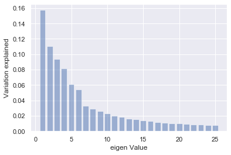

```python
### we shall try to PCA the  POLY..

from sklearn.decomposition import PCA

pca = PCA(n_components=25)
pca.fit(X_poly)

print(pca.explained_variance_)

print(pca.explained_variance_ratio_)

plt.bar(list(range(1,26)),pca.explained_variance_ratio_,alpha=0.5, align='center')
plt.ylabel('Variation explained')
plt.xlabel('eigen Value')
plt.show()
```

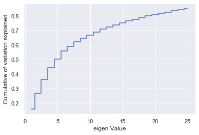

```python
plt.step(list(range(1,26)),np.cumsum(pca.explained_variance_ratio_), where='mid')
plt.ylabel('Cumulative of variation explained')
plt.xlabel('eigen Value')
plt.show()
```

```python
# 95 Per cent qantification
print(pca.explained_variance_ratio_.cumsum())
```

```
[0.15746339 0.2678219  0.36150035 0.44338907 0.5045447  0.55882182
 0.59154222 0.62087845 0.64691537 0.66966322 0.68997687 0.70838176
 0.72432616 0.73938421 0.75352259 0.76650419 0.77843904 0.78966949
 0.79970245 0.80946211 0.81851467 0.82727969 0.83573052 0.84367298
 0.85134274]
```

```python
X_poly_pca = pca.transform(X_poly)
X_poly_pca.shape
```

```
(1030, 25)
```

```python
# Lets try to fit the same poly model as earlier to check accuracy and confirm if PCA is sufficient.

X_poly_PCA_train, X_poly_PCA_test, y_train, y_test = train_test_split(X_poly_pca, y, test_size=0.30, random_state=1)


model = LinearRegression()
model.fit(X_poly_PCA_train, y_train)
y_poly_PCA_pred = model.predict(X_poly_PCA_test)

rmse = np.sqrt(mean_squared_error(y_test,y_poly_PCA_pred))
r2 = r2_score(y_test,y_poly_pred)
print(rmse) # non pca value  0.36
print(r2) #non pca value 0.87

result.loc[8] = ['Linear Reg ridge (PCA=25)', rmse, r2, 'good accuracy']
```

```
0.6579144514618787
0.8756408680570978
```

```python
#SVM
from sklearn import svm
clf_PCA = svm.SVR(gamma=0.01,kernel='rbf',C=10)
clf_PCA.fit(X_poly_PCA_train,y_train)
pred_train = clf_PCA.predict(X_poly_PCA_train)
```

```python
clf_PCA.score(X_poly_PCA_train, y_train)
```

```
0.9585298340444931
```

```python
pred_test = clf_PCA.predict(X_poly_PCA_test)
clf_PCA.score(X_poly_PCA_test, y_test)
```

```
0.8307349425053798
```

```python
rmse = mean_squared_error(y_test,pred_test)
r2 = r2_score(y_test,pred_test)
result.loc[9] = ['SVM (PCA)(rbf kernel)', rmse, r2, 'good accuracy']
```

```python
#KNN REgression

from sklearn.neighbors import KNeighborsRegressor

clf=KNeighborsRegressor(n_neighbors=4, algorithm='auto', weights='distance')
clf.fit(X_poly_PCA_train,y_train)
y_poly_pred=clf.predict(X_poly_PCA_test)
print(mean_squared_error(y_test,y_poly_pred))
print(r2_score(y_test,y_poly_pred))


rmse = mean_squared_error(y_test,y_poly_pred)
r2 = r2_score(y_test,y_poly_pred)

result.loc[10] = ['KNN (poly=3)(PCA=25)(neighbors=4)(weights=distance)', rmse, r2, 'low accuracy']
```

```
0.22321594018460772
0.7861629919074378
```

```python
#Random Forest Regressor
from sklearn.ensemble import RandomForestRegressor
regr = RandomForestRegressor(max_depth=25, random_state=0, n_estimators=100)
regr.fit(X_poly_PCA_train, y_train)
y_poly_pred=regr.predict(X_poly_PCA_test)
print(mean_squared_error(y_test,y_poly_pred))
print(r2_score(y_test,y_poly_pred))

rmse = mean_squared_error(y_test,y_poly_pred)
r2 = r2_score(y_test,y_poly_pred)

result.loc[11] = ['Random Forest Regressor (poly=3)(PCA=25)', rmse, r2, 'good accuracy']
```

```
0.13598020062498647
0.8697333208487474
```

```python
from xgboost import XGBRegressor
xgb_model  = XGBRegressor(max_depth=5, learning_rate=0.2, n_estimators=100, objective='reg:squarederror', booster='gbtree')
xgb_model= xgb_model.fit(X_poly_PCA_train, y_train)
pred_train = xgb_model.predict(X_poly_PCA_train)
pred_test = xgb_model.predict(X_poly_PCA_test)
```

```python
#training score
xgb_model.score(X_poly_PCA_train , y_train)
```

```
0.9912790376393746
```

```python
#Testing score
xgb_model.score(X_poly_PCA_test , y_test)
```

```
0.8630219394753641
```

```python
rmse = mean_squared_error(y_test,pred_test)
r2 = r2_score(y_test,pred_test)

result.loc[12] = ['XG Boost Regressor (poly=3)(PCA=25)(gbtree,max_depth=5)', rmse, r2, 'good accuracy']
```

```python
#Just trying once with NON-PCA
xgb_model  = XGBRegressor(max_depth=5, learning_rate=0.2, n_estimators=100, objective='reg:squarederror', booster='gbtree')
xgb_model= xgb_model.fit(X_train_poly, y_train)
pred_train = xgb_model.predict(X_train_poly)
pred_test = xgb_model.predict(X_test_poly)
```

```python
xgb_model.score(X_train_poly , y_train)
```

```
0.9914277470381362
```

```python
xgb_model.score(X_test_poly , y_test)
```

```
0.8983470086066571
```

```python
result
```

|  | Model | RMS | r2 | Comments |
| --- | --- | --- | --- | --- |
| 0 | Linear Regression | 0.561339 | 0.698138 | Low accuracy explains [r2] percent fit and hig... |
| 1 | Linear Reg Polynomial (Deg=3) | 0.360296 | 0.875641 | good accuracy and low error |
| 2 | Linear Reg Ridge(alpha=0.2) | 0.315103 | 0.698137 | low accuracy and high error |
| 3 | Linear Reg Ridge(alpha=1) | 0.315114 | 0.698126 | low accuracy and high error |
| 4 | Linear Reg lasso (alpha=0.02) | 0.325725 | 0.687961 | low accuracy and high error |
| 5 | Linear Reg lasso(alpha=0.2) | 0.543438 | 0.479395 | very low accuracy and low error |
| 6 | Linear Reg ridge (poly=3)(alpha=0.2) | 0.125286 | 0.879978 | High accuracy |
| 7 | Linear Reg ridge (poly=3)(alpha=0.02) | 0.154661 | 0.851837 | good accuracy |
| 8 | Linear Reg ridge (PCA=25) | 0.657914 | 0.875641 | good accuracy |
| 9 | SVM (PCA)(rbf kernel) | 0.176689 | 0.830735 | good accuracy |
| 10 | KNN (poly=3)(PCA=25)(neighbors=4)(weights=dist... | 0.223216 | 0.786163 | low accuracy |
| 11 | Random Forest Regressor (poly=3)(PCA=25) | 0.135980 | 0.869733 | good accuracy |
| 12 | XG Boost Regressor (poly=3)(PCA=25)(gbtree,max... | 0.142986 | 0.863022 | good accuracy |